# Log Reconstruction from Board Imagery

*JH, Aug 2015*

## Introduction

Often we want to know which boards came from the same log. We are also often interested in where within a log, or within a saw pattern, a particular board came from.

As well as assisting research, the ability to track boards back to logs routinely would be useful to wood processors. For example, are 'bad' boards scattered through many logs or concentrated in a few?

To date, meeting these desires has been addressed by marking the log ends in some fashion, e.g. using barcoded paper labels. This approach is reasonably successful, but requires time-consuming preparation (expensive, inconvenient, prevents integration with existing mill practices) and cannot be used outside of specific research projects (i.e. it cannot be incorporated in normal production).

An alternative approach is to use board imagery, collected as part of a board grading operation, to assign boards to logs and to reconstruct saw pattern. This imagery may be of the board surface (e.g. VIS) or volume (e.g. XRY).

The Hyne (SWI LS.1.6) dataset contains such imagery from both USNR Lineal High Grader at in the Hyne dry mill and the Microtec Gradescan at CHH (although the latter is yet to be unpacked from the .brt files). This imagery allows us to test log reconstruction from board imagery.

## Approach

Two obvious approaches to test:

1. Cluster boards based on similarity of features along length (e.g. knots). Do these clusters correspond to logs?
2. Pair up boards using surface grain (and defect) patterns to match opposing faces. Use these pairings to reconstruct saw pattern and hence assign to a log. Three levels of pairing could be attempted:
   1. Pair wide faces - useful on its own to reconstruct cant
   2. Pair narrow faces - in conjunction with wide face pairings would yield saw-pattern for full length boards
   3. Partial face pairings - required to recover position in saw-pattern of boards shortened due to either log shape (taper, sweep, etc) or trimming

## Visual Inspection

After collating and visually inspecting the VIS and XRY imagery (see `catalog()` in `logrecon.py` and `xry_dfa_vis.html`):

1. Left and Right board imagery is very distorted due to board motion in the scanner. Substantial work would be required (e.g. using LPR data to 'straighten') if imagery from these faces needs to be used.
2. Unsurprisingly knots show up reasonably clearly in the XRY imagery. A simple global absorption threshold suffices to detect many knots, but more complicated procedures will be required to recognise the remainder. Fortunately USNR have already done this and a list of defects, their sizes and positions are available in the `DFADefectsOut_*.txt` files.
3. All the scanner imagery has artifacts e.g. vertical stripes in XRY
4. Light intensity varies greatly between Top and Bottom surfaces in VIS. This would need to be allowed for if grain patterns on opposing surfaces are to be matched.
5. XRY and VIS are on different grids, and the relationship between these grids is not precisely known (but is able to be guessed).

XRY imagery and whorl structure appears to be best route to clustering boards by log. Drawbacks: useless for pruned logs, better for longer boards with more knots.

## Clustering by Log

### Board description vector

A 1-D board description suitable for clustering boards might be arrived at in a variety of ways:

1. as continuous function of position along length, e.g. by summarizing (average, minimum, etc) the XRY data across the board width
2. as a binary feature vector (whorl/not-whorl) on a grid e.g. based on a thresholding of the XRY data tuned to distinguish knots from clearwood
3. as a list of knot sizes and positions e.g. USNR defect data filtered to describe only knots

All of these approaches have been trialled. The latter two appear more promising, mainly because the first is strongly influenced by clearwood variation, which, unlike knot position, is not expected to be similar in all boards from the same log.

### Clustering

There are many different approaches to data clustering [Fahad2014]. For current purposes, an agglomerative hierarchical algorithm has been used principally because it yields a dendrogram showing how boards form clusters of different sizes, rather than just returning the number of clusters requested.

As important as the choice of clustering method, is the choice of distance (or similarity) measure. Again there are many possible choices [Choi10]. A number of these have been explored, and a tailor made algorithm found to be the best (see `logrecon.ddfa()`).

An example clustering of boards, based on the USNR defect data, is shown below. For legibility only boards from the first 5 logs in the dataset have been clustered. The result shown is typical of a wide range of distance metrics and alogorithm options. Similar results are obtained using either binarised XRY data or USNR defect data.

Nodes in the resulting dendrogram represent boards, and are labelled L-BBBBBBB where L is the log number and BBBBBBB is the board identifier. Distance from the right hand edge of the plot is a measure of dissimilarity.

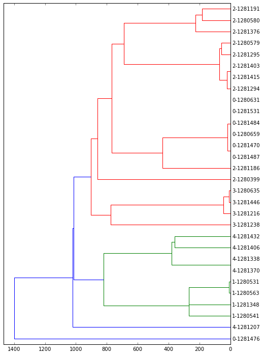

```python
%matplotlib inline
import pylab
pylab.rcParams['figure.figsize'] = (8.0, 12.0)
from logrecon import knot, fetch_dfa, ddfa, pdist_dfa
boards = fetch_dfa(force_reload=True)
B = []
labels = []
off = 0
for b in boards:
    if int(b['log'])<105:
        B.append([])
        for Def, Sys, Srfc, MinX, MaxX, MinY, MaxY, MinZ, MaxZ in b['raw']:
            B[-1].append(knot(MinX,MaxX))
        labels.append('%i-%i' % (int(b['log'])-100, b['board']))

# compute distances
Y = pdist_dfa(B,ddfa)

# cluster
from scipy.cluster.hierarchy import linkage
Z = linkage(Y)

# draw the dendrogram
from scipy.cluster.hierarchy import dendrogram
R = dendrogram(Z, labels=labels, orientation='right')
#plt.show()
```

## Discussion

Restricting the search space (by reducing the number of candidate match boards) makes both the clusting and saw pattern reconstruction problems easier. In a green mill, if boards from a given log are flushed through in a reasonably short time, then the search space can be restricted by time-of-processing. However, the type of scan data required is unlikely to be available in a green mill, and in a dry-mill, where the scan data is potentially available, boards from different logs are already well mixed. Furthermore, in the dry-mill boards have been trimmed and boards from a single log will be scattered through numerous packs of differnt product types.

If log measurments need to be associated with board measurements (very often the case in a research context) then even if boards can be grouped by log, this still leaves the problem of deciding which log each grouping represents. One way to do this might be to arrange for every log to have a similar but measurably different length, then use board length to assign log number to a set of boards clustered by log.

# Conclusions

1. Visual inspection suggests that board surface imagery (at least from LHG) appears to contain enough information to recostruct logs
2. Knot structure alone is insufficient to fully assign boards to log, but is useful for identifying boards that do not come from the same log.
3. By using knot structure to reject potential board pairings, the search space for a surface pattern match search is greatly reduced, rendering such feasible.

Next:

- Since Ecambium project has opted for full barcode approach, there's no urgent need to pursue this
- Surface pattern pairing is the next step
- Would be good to have narrow face imagery as well as wide face
- How to relate log level measurements made prior to sawing to reconstructed logs (i.e. having found all the boards from a log, determine which log). Log size, length and time-of-processing might play a role here, but probably extra information will also be required (e.g. matching log CT to board knot structure).
- Would missing material (e.g. broken boards or boxed out pith etc) prevent pairings from being used to fully assign boards to logs?
- In theory, how much 'information' should be needed to assign boards to logs based on whorl 'fingerprint'?

# References

A. Fahad, et. al. 2014. A Survey of Clustering Algorithms for Big Data: Taxonomy & Empirical Analysis. *Emerging Topics in Computing*. 2(3):267-279.

Seung-Seok Choi, et. al. 2010. A Survey of Binary Similarity and Distance Measures. *Systemics, Cybernetics and Informatics*. 8(1):43-48.